# データ解析のための統計モデリング

**データ解析のための統計モデリング(久保拓弥著)**を読んで学んだ知識をまとめる  
また、個人的に有用だと感じた部分のみ抜粋

# １ データを理解するために統計モデルを作る

統計モデルは、  
・観察によってデータ化された**現象を説明するため**に作られる  
・確率分布が**基本的な部品**であり、これはデータに見られるばらつきを表現する**手段**である  
・データとモデルを対応づける手続きが準備されていて、モデルがデータにどれぐらい良く当てはまっているかを定量的に評価できる  
といった特徴を持つ**数理モデル**である

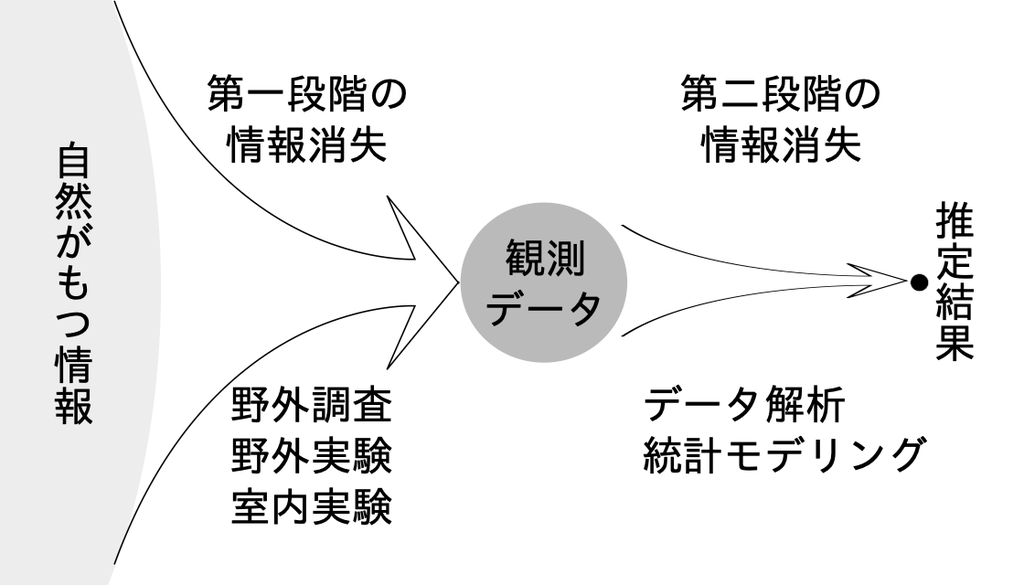

自然科学では、現象の観測や実験で得られたデータに対して、人間の解釈を当てはめて、その背後にある**「自然の仕組み」**を理解しようとした時に上図のように**２段階**の情報消失が発生すると考える。

確率分布はデータ化において必然的に発生する様々な種類の**誤差をモデル化する**ために必要

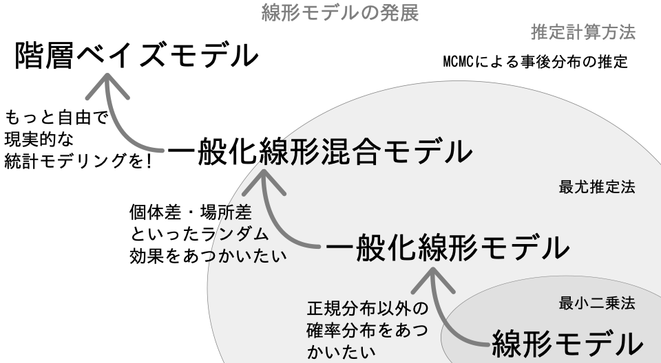

# ２ 確率分布と統計モデルの最尤推定

**確率分布**は統計モデルの本質的な部品であり、データに見られる様々な**「ばらつき」**を表現する

**最尤推定法**は尤度なる「当てはまりの良さ」を表す統計量を最大にするようなパラメタの値を探そうとするパラメタ推定方法である

統計モデルの良さを評価するときに、**予測の良さ（goodness of prediction）**と言う考え方が重要。観測データはあくまで母集団の一部であり、関心事項は観測データの背後にある母集団である。そのため、同じ母集団から得られた異なる観測データにおける当てはまりの良さも評価し、特定の観測データに依存しない不偏な統計モデル評価を行う。

# ３ 一般化線形モデル（GLM）ーポアソン回帰ー

まず**回帰とは、応答変数について説明変数を使った式で表すこと**。別の言い方では、応答変数と説明変数の間にモデルを当てはめること。

一般化線形モデルでは**残差を任意の分布に仮定**できるのが特徴。また、残差を任意の分布に仮定する上で分布の制約等を線形モデルに反映させる必要あり。その役割をリンク関数が担う。（具体的には応答変数の期待値を線形予測子の左辺とし、期待値が分布の制約を満たすように変換する関数をリンク関数と呼ぶ）

ポアソン回帰は、応答変数がポアソン分布に従う回帰である。

```r
setwd("/Volumes/GoogleDrive/My Drive/Upside-prefecture/Other/データ解析のための統計モデリング/poisson")
d <- read.csv("data3a.csv")
#dは100行3列. yは種子数, xは体サイズ, fは肥料の有無.

#y:種子数をx:体サイズで説明。種子数はポアソン分布に従うと仮定。
fit <- glm(y ~ x, data = d, family = poisson)
fit
```

```
##
## Call:  glm(formula = y ~ x, family = poisson, data = d)
##
## Coefficients:
## (Intercept)            x
##     1.29172      0.07566
##
## Degrees of Freedom: 99 Total (i.e. Null);  98 Residual
## Null Deviance:       89.51
## Residual Deviance: 84.99     AIC: 474.8
```

```r
logLik(fit)#最大対数尤度(dfは自由度：変数の数)。
```

```
## 'log Lik.' -235.3863 (df=2)
```

```r
#y:種子数をf:肥料の有無で説明。種子数はポアソン分布に従うと仮定。
fit.f <- glm(y ~ f, data = d, family = poisson)
fit.f
```

```
##
## Call:  glm(formula = y ~ f, family = poisson, data = d)
##
## Coefficients:
## (Intercept)           fT
##     2.05156      0.01277
##
## Degrees of Freedom: 99 Total (i.e. Null);  98 Residual
## Null Deviance:       89.51
## Residual Deviance: 89.48     AIC: 479.3
```

```r
logLik(fit.f)
```

```
## 'log Lik.' -237.6273 (df=2)
```

```r
#y:種子数をx:体サイズとf:肥料の有無で説明。種子数はポアソン分布に従うと仮定。
fit.xf <- glm(y ~ x + f, data = d, family = poisson)
fit.xf
```

```
##
## Call:  glm(formula = y ~ x + f, family = poisson, data = d)
##
## Coefficients:
## (Intercept)            x           fT
##     1.26311      0.08007     -0.03200
##
## Degrees of Freedom: 99 Total (i.e. Null);  97 Residual
## Null Deviance:       89.51
## Residual Deviance: 84.81     AIC: 476.6
```

```r
logLik(fit.xf)
```

```
## 'log Lik.' -235.2937 (df=3)
```

```r
#y:種子数を定数(1)で説明。種子数はポアソン分布に従うと仮定。
fit.null <- glm(y ~ 1, data = d, family = poisson)
fit.null
```

```
##
## Call:  glm(formula = y ~ 1, family = poisson, data = d)
##
## Coefficients:
## (Intercept)
##       2.058
##
## Degrees of Freedom: 99 Total (i.e. Null);  99 Residual
## Null Deviance:       89.51
## Residual Deviance: 89.51     AIC: 477.3
```

```r
logLik(fit.null)
```

```
## 'log Lik.' -237.6432 (df=1)
```

結果として、モデルの書き方と、データとモデルの当てはまりを表す指標である最大対数尤度を読み取れればこの段階では良いと思う

# ４ GLMのモデル選択 ーAICとモデルの予測の良さー

モデル選択とは**良い予測をする**モデルを探すことであって、観測データへの当てはまりの良さだけで選んではいけない。

**逸脱度(deviance)**は以下の式で定義され、logL*は最大対数尤度を示す。-2が掛けられているので、逸脱度Dは当てはまりの悪さの指標となる。

$$D = -2logL^*$$
また、パラメタ数(k) を増やすほど残差逸脱度(逸脱度-フルモデルの逸脱度)は小さくなる性質がある。従って、パラメタ数(k)と言うバイアスを考慮した当てはまりの指標が必要となる。統計モデルにおける自由度はパラメタ数と同値である。
パラメタ数の多い統計モデルほど、データへの当てはまりが良くなるが、それは**たまたま得られたデータへの当てはめ向上を目的とする特殊化**であり、その統計モデルの予測の良さを損なっているかもしれない。

平均対数尤度は統計モデルの予測の良さの指標である。観測データと同じ母集団から得られた別のデータ（評価用データ）に対して統計モデルの対数尤度を計算し、対数尤度の平均（平均対数尤度）を取ることで予測の良さを評価する。

特定データでの尤度と平均対数尤度の差をバイアスと呼ぶ。
$$b = logL^* - E(logL)$$

しかし、現実のデータ解析では、母集団は未知であるためE(logL):平均対数尤度が不明である。
そのため、バイアスbの定義を変形し、
$$E(logL) = logL^* - b$$
とし、bを自由度(k)に置き換えて、-2を掛けると自由度を考慮した逸脱度となる。これをAICと呼ぶ。
$$AIC = -2(logL^*-k)$$